# CHAPTER C9

# 曲面外板パネルの座屈強度。補強された曲面外板構造の極限強度

## PART 1. 曲面外板パネルの座屈強度

### C9.1 はじめに

曲面外板パネルは、飛行体の構造における一般的な外面要素を構成している。例としては、胴体やミサイルの外皮が挙げられる。もし曲面外板に縦方向の補強材（スチフナ）がない場合、座屈が発生した時点で破壊が起こる。曲面外板に補強要素が取り付けられている場合、外板の座屈が発生しても複合ユニット自体は破壊されない。すなわち、複合ユニットは、補強材の間の曲面外板パネルに初期座屈を生じさせた荷重よりもはるかに大きな極限強度を有する。この補強要素は一般に外板スチフナと呼ばれる。一部の飛行体設計においては、制限荷重の特定の割合以下では曲面外板パネルの座屈が発生しないことを規定する場合がある。したがって、どのような応力によって曲面外板パネルが座屈するかを判断でき、また、どのような外力が加わったときに補強外板パネルが破壊するかを決定できる必要がある。

### C9.2 理論の現状

第A18章では、平板パネルの圧縮座屈応力を決定するために、小たわみ線形理論が使用された。理論値は実験結果と良好に一致している。しかし、同じ理論を補強されていない曲面外板パネルや薄肉円筒に適用すると、理論値はこれらの試験結果をかなり上回る。大たわみ理論は試験結果とより近い一致を示すが、この理論は外板の初期不整を考慮する必要があり、したがって未知の量を含んでいる。曲面外板および円筒の座屈に対する小たわみおよび大たわみ理論の両方の適用については、第C8章の末尾に記載されている参考文献、特にDonnell、Batdorf、Gerardなどの研究者の結果を示す報告書を参照されたい。

### C9.3 曲面外板パネルの圧縮座屈応力

軸圧縮下の座屈応力の式は平板の場合と同じ形式であり、座屈係数 $K_c$ の値がより大きくなる。

$$F_{ccr} = \frac{K_c \pi^2 E}{12 (1 -
u_e^2)} \left(\frac{t}{b}\right)^2 \quad \cdots \text{C9.1}$$

図C9.1は座屈係数 $K_c$ を決定するための曲線を示している。理論的に導出された曲線が、試験結果から規定された推奨設計曲線とともに示されている。これらの曲線は弾性範囲における座屈応力に適用される。

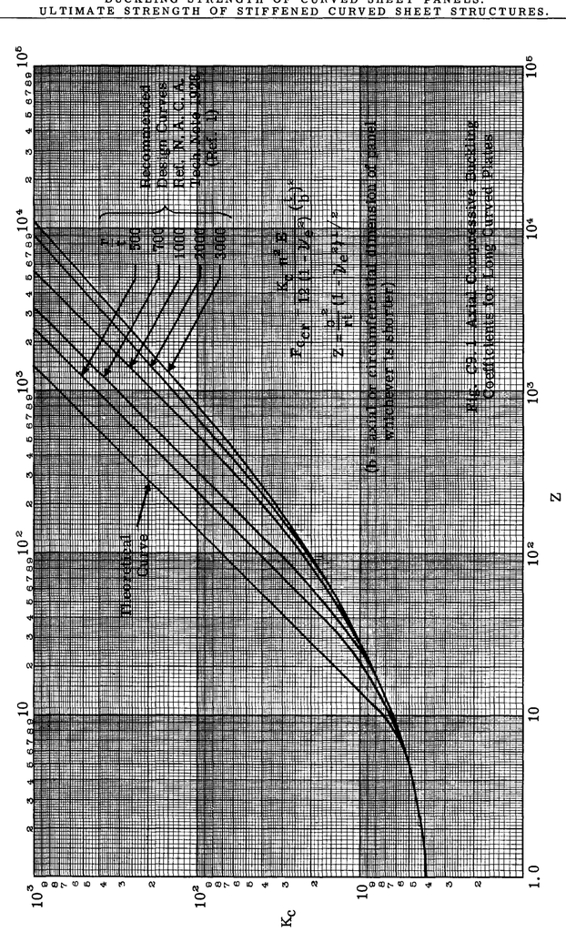

図C9.1

### C9.4 曲面外板パネルのせん断座屈応力

座屈せん断応力の式は以下の通りである。

$$F_{scr} = \frac{K_s \pi^2 E}{12 (1 -
u_e^2)} \left(\frac{t}{b}\right)^2 \quad \cdots \text{C9.2}$$

図C9.2からC9.5は、式C9.2で使用する座屈応力係数 $K_s$ を求めるための曲線を示している。これらの曲線は座屈応力が弾性範囲にある場合に適用される。

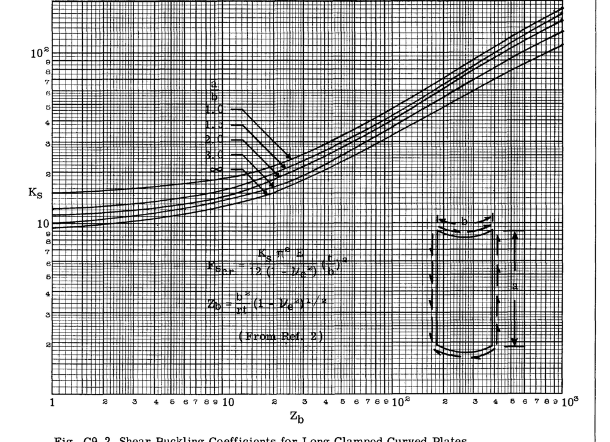

図C9.2

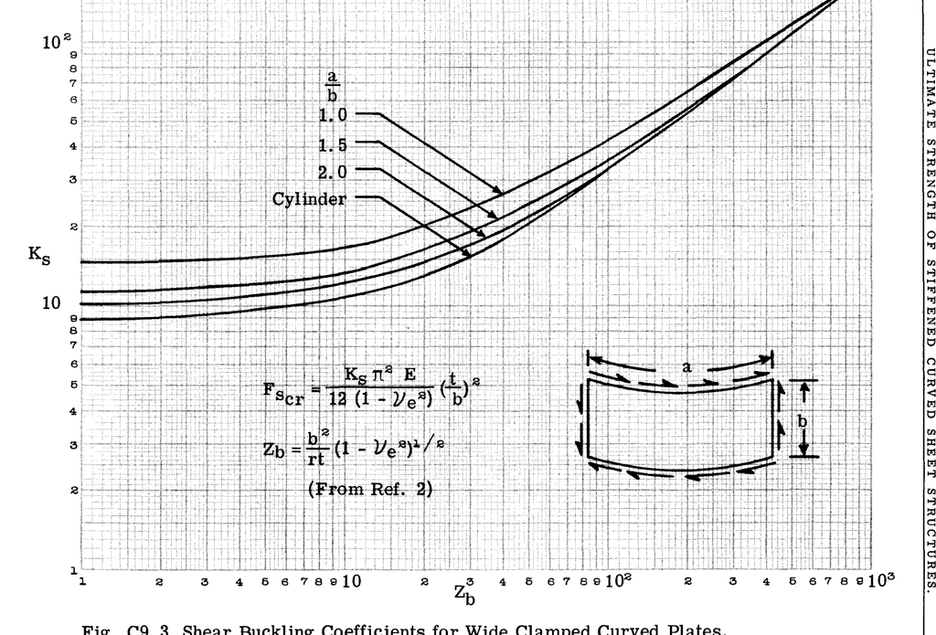

図C9.3

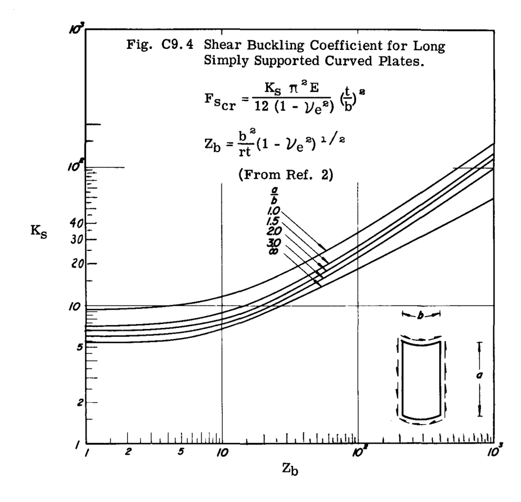

図C9.4

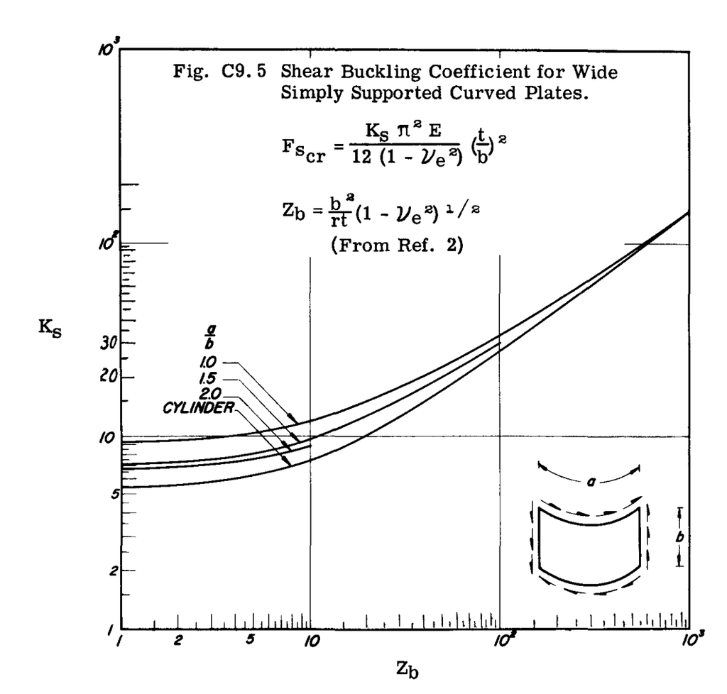

図C9.5

### C9.5 軸圧縮とせん断の複合荷重を受ける曲面外板パネルの座屈強度

SchildcroutとSteinによる研究（文献1）は、曲面外板パネルにおける縦方向圧縮とせん断の複合荷重に対して、以下の相互作用式を与えた。

$$R_s^2 + R_L = 1 \quad \cdots \text{C9.3}$$

ここで、

$$R_s = \frac{f_s}{F_{scr}}, \quad R_L = \frac{f_c}{F_{ccr}}$$

縦方向の応力が圧縮ではなく引張である場合、 $R_L$ は圧縮許容値を使用した負の圧縮として考慮される。安全余裕（M.S.）の式は以下の通りである。

$$\text{M.S.} = \frac{2}{R_L + \sqrt{R_L^2 + 4 R_s^2}} - 1 \quad \cdots
\text{C9.4}$$

### C9.6 内圧を受ける曲面パネルの圧縮座屈応力

モノコック円筒の場合と同様に、内部の外向きの圧力は、曲面外板パネルの軸圧縮座屈応力を増加させる。RafelとSandlin（文献3）およびRafel（文献4）は、軸圧縮と内部外向き圧力を受ける曲面パネルの試験を実施した。その結果は以下の相互作用式と相関している。

$$R_c^2 + R_p = 1 \quad \cdots \text{C9.5}$$

ここで、 $R_c = f_c / F_{ccr}$

$$R_p = \text{比率} \left[
\frac{\text{作用する内圧}}{\text{曲面パネルがその一部である円筒を座屈させる外向き外圧}}
\right]$$

（第C8章の図C8.16を用いて求められる）

式C9.5を使用する際、内圧は内向きに作用する外圧と反対方向であるため、 $R_p$ の値は負となる。

### C9.7 内圧を受ける曲面外板パネルのせん断座屈応力

モノコック円筒の場合と同様に、内圧は曲面外板パネルのせん断座屈応力を増加させる。BrownとHopkins（文献5）は、曲面パネルのせん断座屈応力に対する放射状の外向き圧力の影響を決定するために、古典的な平衡方程式を解き、RafelとSandlin（文献3）による試験データと良好な一致を得た。試験データは、ねじりを受ける円筒に対する内圧の影響に使用される相互作用曲線とも相関している（第C8章を参照）。相互作用式は以下の通りである。

$$R_s^2 + R_p = 1 \quad \cdots \text{C9.6}$$

ここで、 $R_s = f_s / F_{scr}$

$$R_p = \text{比率} \left[
\frac{\text{作用する内圧}}{\text{曲面外板パネルがその一部である円筒を座屈させる外向き外圧}}
\right]$$

（第C8章の図C8.16を用いて求められる）

式C9.6を使用する場合、 $R_p$ には負の符号が与えられる。

### C9.8 計算例

#### 問題 1

図C9.6は、小さな円で表される縦方向のスチフナを持つ円形胴体断面を示している。各スチフナの断面積は $0.15 \text{ sq. in.}$ である。外板の厚さは $0.04 \text{ inches}$ である。すべての材料はアルミニウム合金であり、 $E_c = 10,700,000$ である。胴体フレームの間隔（ $a$ ）は $15.75 \text{ inches}$ である。胴体断面には、以下の荷重システムが作用している。

$M_y = 600,000 \text{ in.lb.}$ （上半分に圧縮を引き起こす）  
$V_z = 5175 \text{ lbs.}$ （上向きに作用）  
$T = \text{ねじりモーメント} = 210,000 \text{ in.lbs.}$ （反時計回りに作用）

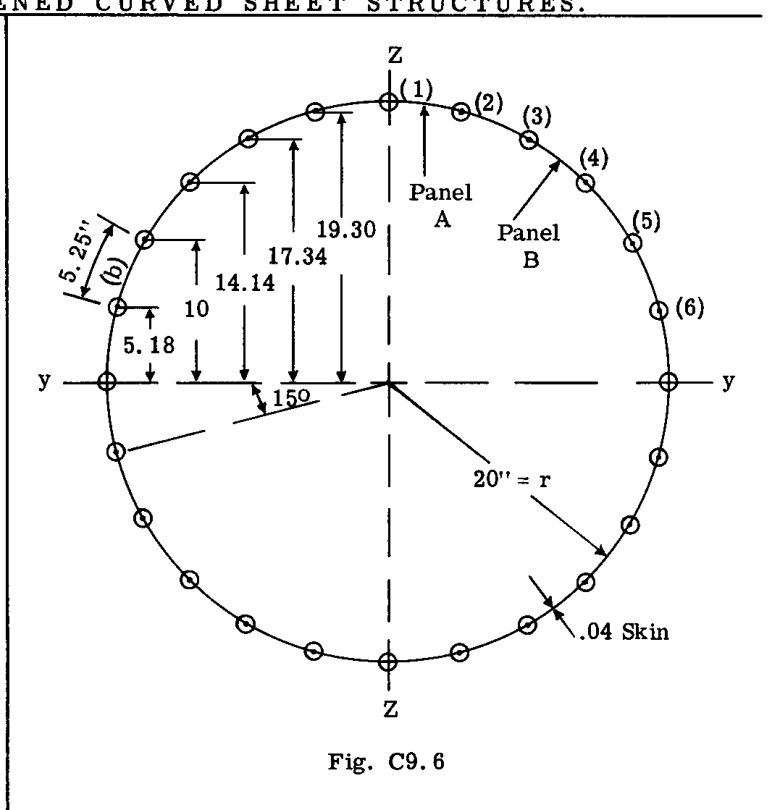

図C9.6

問題は、与えられた胴体断面への複合荷重の下で、外板パネル（A）および（B）が座屈するかどうかを判断することである。

#### 解法

曲げ応力を求めるには、 $y-y$ 軸に関する断面二次モーメントが必要である。すべての材料が有効であるため、この軸は中立軸でもある。断面二次モーメントは、1つの象限の材料によるものの4倍に等しくなる。

スチフナによる $I_y$ は、

$$I_y = 4 \left[ .075 \times 20^2 + .15 (19.30^2 + 17.34^2 + 14.14^2 +
10^2 + 5.18^2) \right] = 720 \text{ in.}^4$$

外板によるもの：

$$I_y = \pi r^3 t = \pi \times 20^3 \times .04 = 1005 \text{ in.}^4$$

$$\text{Total } I_y = 720 + 1005 = 1725 \text{ in.}^4$$

外板パネル (A) について考える：

$$r/t = 20/.04 = 500, \quad a/b = 15.75/5.25 = 3.0$$

圧縮座屈応力を決定するために、図C9.1を用いて座屈係数 $K_c$ を求める。

$$Z = \frac{b^2}{rt} (1 -
u_e^2)^{1/2}$$

$$= \frac{5.25^2}{20 \times .04} (1 - .3^2)^{1/2} = 32.9$$

図C9.1より、 $K_c = 14$

$$F_{ccr} = \frac{K_c \pi^2 E}{12 (1 -
u_e^2)} \left(\frac{t}{b}\right)^2$$

$$= \frac{14 \pi^2 \times 10,700,000}{12 (1 - .3^2)}
\left(\frac{.04}{5.25}\right)^2 = 7850 \text{ psi}$$

せん断座屈応力を求めるために、図C9.2を使用する。 $Z$ は上記で計算したものと同じ、すなわち $32.9$ である。したがって、図C9.2から $a/b = 3$ に対して、 $K_s = 20$ を読み取る。

$$F_{scr} = \frac{20 \pi^2 \times 10,700,000}{12 (1 - .3^2)}
\left(\frac{.04}{5.25}\right)^2 = 11,200 \text{ psi}$$

パネル (A) の中央における曲げ応力を計算する：

$$f_c = M Z / I_y = (600,000 \times 19.7) / 1725 = 6850 \text{ psi}$$

したがって、応力比 $R_c = f_c / F_{ccr} = 6850 / 7850 = .874$

ねじりによるパネル (A) のせん断応力は、

$$f_s = T / 2At$$

ここで、 $A$ は胴体セルの囲まれた面積である。

$$f_s = 210,000 / (2 \times \pi \times 20^2 \times .04) = 2090 \text{ psi}$$

パネルはまた、 $V_z = 5175 \text{ lbs.}$ の横せん断によるせん断応力も受ける。

せん断流の式は、

$$q = - \frac{V_z}{I_y} \Sigma Z A = - \frac{5175}{1725} \Sigma Z A = - 3
\Sigma Z A$$

せん断流は $Z$ 軸上でゼロになる。パネル (A) の上端におけるせん断流は、スチフナ (1) の面積の半分による影響となる。

$$q_{1-2} = - 3 \times .075 \times 20 = - 4.5 \text{ lb./in.}$$

スチフナ (1) と (2) の間の外板の面積は $5.25 \times .04 = .21 = A$ である。

中立軸からのパネル (A) の図心距離は $Z = r \sin \alpha / \alpha$ である。 $\alpha = 15^\circ$ であり、これより $Z = 19.8 \text{ in.}$ を得る。

したがって、

$$q_{2-1} = - 4.5 - 3 \times .21 \times 19.8 = - 17 \text{ lb./in.}$$

したがって、パネルの平均せん断流は、

$$(17 + 4.5) / 2 = 10.75$$

したがって、せん断応力 $= q/t = 10.75 / .04 = 269 \text{ psi}$

このせん断応力は、ねじりせん断応力と同じ方向を持つため、2つを足して真のせん断力を得る、または：

$$f_{s(\text{total})} = 269 + 2090 = 2359 \text{ psi}$$

そのとき、せん断応力比 $R_s = f_s / F_{scr} = 2359 / 11200 = .21$

曲げ圧縮とせん断の複合荷重に対する相互作用式は、

$$R_c + R_s^2 = 1$$

$$.874 + .21^2 = .918$$

これは $1.0$ 未満であるため、パネルは座屈しない。

$$\text{M.S.} = \frac{2}{.874 + \sqrt{.874^2 + 4 \times .21^2}} - 1 = .09$$

外板パネル (B) について考える。

パネルの中央までのアーム $Z = 15.88 \text{ in.}$

$$f_c = M z / I = 600,000 \times 15.88 / 1725 = 5520 \text{ psi}$$

$$R_c = 5520 / 7850 = .704$$

ねじりせん断応力はすべてのパネルで同じ、すなわち以前計算したように $f_s = 2090 \text{ psi}$ である。

横せん断荷重によるせん断流 $q$ ：

$$q = \frac{V}{I} \Sigma Z A = 3 \Sigma Z A$$

パネル上端における $\Sigma Z A$ の計算：

スチフナについて $= .075 \times 20 + .15 (19.3 + 17.34) = 7.0$

外板について： $\text{面積} = 2 \times 5.25 \times .04 = .42$

外板部分の図心までの鉛直距離 $\bar{Z} = r \sin \alpha / \alpha$ 。 $\alpha = 30^\circ$ 。結果は $\bar{Z} = 19.1 \text{ in.}$ 。 $\bar{Z} A = 19.1 \times .42 = 8.03$ 。 $\text{合計} \Sigma Z A = 8.03 + 7.0 = 15.03$ 。したがって、 $q = 3 \Sigma Z A = 3 \times 15.03 = 45.09 \text{ lb./in.}$

パネル (B) の下端におけるせん断流の同様の計算により、 $q = 55.0$ を得る。したがって、パネル上の平均せん断流は $(55 + 45.09)/2 = 50.04$ 。そのとき $f_s = q/t = 50.14 / .04 = 1251 \text{ psi}$ 。パネル上の総せん断応力 $f_s$ は $1251 + 2090 = 3341 \text{ psi}$ となる。

$$R_s = f_s / F_{scr} = 3341 / 11200 = .299$$

相互作用式 $R_c + R_s^2$ に代入すると、 $.704 + .299^2 = .793$ 。この結果は $1.0$ 未満であるため、パネルは座屈しない。

学生は、他のパネルについても座屈をチェックし、それらの安全余裕を比較する必要がある。